# ISYE 6402 Homework 8

# Background

We have explored how various U.S. economic indicators are related to each other, which is a classic application for the VAR modeling. In this problem, we will study the inter-dependence and Granger causality between various economic indicators.

# Instructions on reading the data

To read the data in `R`, save the file in your working directory (make sure you have changed the directory if different from the R working directory) and read the data using the `R` function `read.csv()`

```r
# Read the monthly and quarterly data
#fname <- file.choose()
data <- read.csv('QDataR.csv')
#fname2 <- file.choose()
data2 <- read.csv('MDataR.csv')
date.quarter <- as.Date(data[,1],"%m/%d/%Y")
date.month <- as.Date(data2[,1],"%m/%d/%Y")
```

Here are the libraries you will need:

```r
library(data.table)
library(vars)
library(xts)
library(mgcv)
library(stats)
library(tseries)
library(aod)
```

# Question 1: Univariate Analysis

## Question 1a

Plot the time series of all indicators for comparison and discuss whether you find any similarities in terms of trend or other features. Plot also the 1st order difference plots and the corresponding ACF plots. Interpret in terms of stationarity and volatility.

Keep in mind, 2 variables have monthly data, while three have quarterly data. You will need to standardise all into quarterly data time series in order to effectively answer all questions below.

```r
# transform into time series
gdp.ts <- xts(data$GDP, date.quarter)
expgs.ts <- xts(data$EXPGS, date.quarter)
imgpgsc.ts <- xts(data$IMPGSC1, date.quarter)
unrate.ts <- xts(data2$UNRATE, date.month)
pce.ts <- xts(data2$PCE, date.month)

# merge into multivariate time series
ts.merge <- merge(gdp.ts, expgs.ts, join = 'inner')
ts.merge <- merge(ts.merge, imgpgsc.ts, join = 'inner')
ts.merge <- merge(ts.merge, unrate.ts, join = 'inner')
ts.merge <- merge(ts.merge, pce.ts, join = 'inner')
colnames(ts.merge) <- c("tsgdp", "tsexpgs", "tsimgpsc", "tsunrate", "tspce")
```

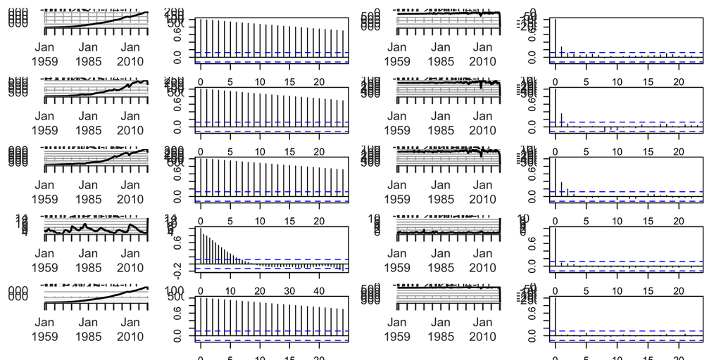

```r
quarter_ind = seq(1,738,3)
unrate.q.ts = unrate.ts[quarter_ind]
pce.q.ts = pce.ts[quarter_ind]

diff_gdp = diff(gdp.ts, lag = 1)
diff_expgs = diff(expgs.ts, lag = 1)
diff_imgpgsc = diff(imgpgsc.ts, lag = 1)
diff_unrate = diff(unrate.q.ts, lag = 1)
diff_pce = diff(pce.q.ts, lag = 1)

par(mfrow = c(5,4), mar = c(1,1,1,1),mpg=c(0.5,0.5,0.5,0.5),oma = c(0.5,0.5,0.5,0.5))
plot(gdp.ts)
acf(gdp.ts,lag.max = 24)
plot(diff_gdp)
acf(diff_gdp[2:246])

plot(expgs.ts)
acf(expgs.ts,lag.max = 24)
plot(diff_expgs)
acf(diff_expgs[2:246])

plot(imgpgsc.ts)
acf(imgpgsc.ts,lag.max = 24)
plot(diff_imgpgsc)
acf(diff_imgpgsc[2:246])

plot(unrate.q.ts)
acf(unrate.q.ts,lag.max = 48)
plot(diff_unrate)
acf(diff_unrate[2:246])

plot(pce.q.ts)
acf(pce.q.ts,lag.max = 24)
plot(diff_pce)
acf(diff_pce[2:246])
```

*Response*

```
Comparing the time series plots, the gdp, export, import as well as PCE all move in the same trend in general. This proves to be consistent to traditional economic theory that trade and consumption drives the GDP up. The unemployment rate does not show a clear trend but does show some level of seasonality. The acf plots show nonstationarity for all the factors, which can also be reflected in the differenced time series plots, where the difference gets larger between 2000 and 2010. The ACF of the differenced data also show good stationality.
```

## Question 1b

Using the original, undifferenced data, divide the GDP data into training data including the data for years 1959 to 2019 with the last two quarters being the testing data. Fit the trend using the splines regression to the GDP training time series. Then, apply ARMA to the residuals obtained from this splines fitting. Use max order of 6. Evaluate goodness of fit for the ARMA model. Forecast the first two quarters of 2020 (testing data) and compare to the observed values. Discuss why there are (or not!) significant differences between predicted vs observed. To do this, you should also evaluate the prediction intervals with a 95% confidence level.

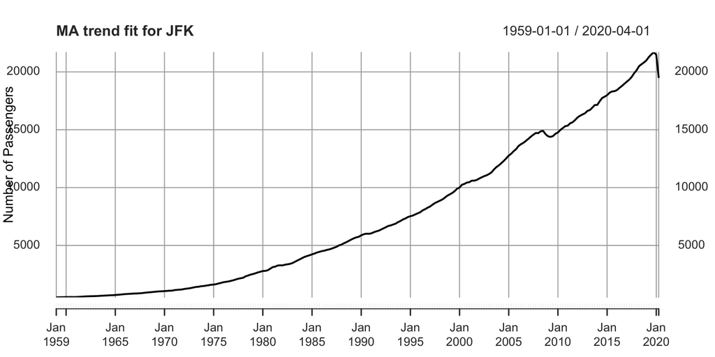

```r
train_gdp  <- head(gdp.ts, 244)
test_gdp <- tail(gdp.ts,2)

time.pts = c(1:length(train_gdp))
time.pts = c(time.pts - min(time.pts))/max(time.pts)
gdp.sp.fit  = gam(train_gdp~s(time.pts))
gdp.sp.fit.ts = xts(fitted(gdp.sp.fit), date.quarter[1:244])
#gdp.sp.fit.ts = ts(fitted(gdp.sp.fit), start = c(1959,1), end=c(2020,4), frequency = 4)

plot(gdp.ts,ylab="Number of Passengers", main="MA trend fit for JFK")
```

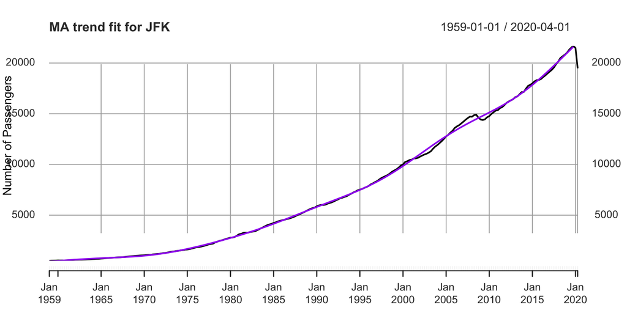

```r
lines(gdp.sp.fit.ts,lwd=2,col="purple")
```

```r
test_model <- function(data,p,q){
    mod = arima(data, order=c(p,0,q), method="ML")
    current.aic <- AIC(mod)
    current.aic<-current.aic-2*(p+q+1)+2*(p+q+1)*length(data)/(length(data)-p-q-2)
    df = data.frame(p,q,current.aic)
    names(df) <- c("p","q","AIC")
    #print(paste(p,q,current.aic,sep=" "))
    return(df)
}

gdp_orders <- data.frame(Inf,Inf,Inf)
names(gdp_orders) <- c("p","q","AIC")
for (p in 0:6){
    for (q in 0:6) {
        possibleError <- tryCatch(
            gdp_orders<-rbind(gdp_orders,test_model(train_gdp,p,q)),
            error=function(e) e
        )
        if(inherits(possibleError, "error")) next
    }
}

gdp_orders <- gdp_orders[order(-gdp_orders$AIC),]
tail(gdp_orders)
```

```
##    p q      AIC
## 34 5 4 2671.477
## 39 6 2 2671.237
## 29 4 5 2667.387
## 30 4 6 2665.093
## 25 3 6 2661.530
## 27 4 1 2652.437
```

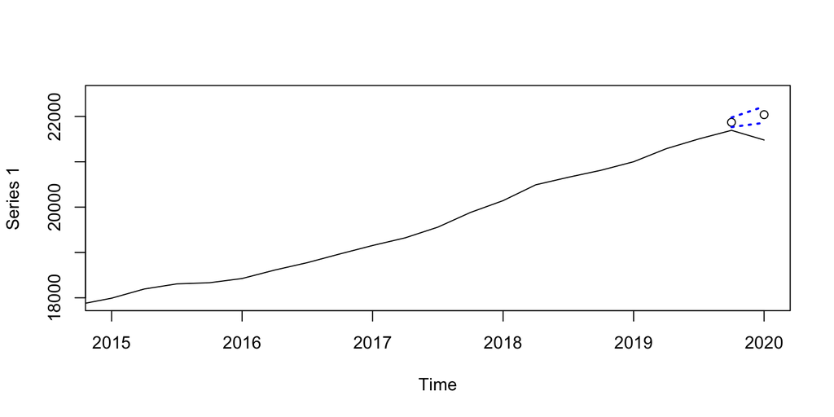

```r
library(forecast)
selected.arma <- stats::arima(train_gdp, order=c(4,0,1), method="ML")

# gdp_pred = predict(selected.arma, n.ahead)
gdp_pred = forecast(selected.arma, h=2, level = 95)

plot(ts(gdp.ts,start = c(1959,1), end = c(2020,1),frequency = 4),xlim=c(2015,2020), ylim = c(17900,22500))
points(ts(gdp_pred$mean,start = c(2019,4), end = c(2020,1),frequency = 4))

# outpred = predictselected.arma,n.ahead=2)
ubound = ts(gdp_pred$lower,start = c(2019,4), end = c(2020,1),frequency = 4)#confidenec interval
lbound = ts(gdp_pred$upper,start = c(2019,4), end = c(2020,1),frequency = 4)
# ymin = min(exp(lbound))
# ymax = max(exp(ubound))
# dates.diff = dates[-c(1:12)]
# n = length(diff.consump)
# plot((dates.diff)[(n-n_forward-20):n],exp(diff.consump[(n-n_forward-20):n]),type="l", ylim=c(ymin,ymax), xlab="Weeks", ylab="12-Lag Diff Log Consumption")
# points((dates.diff)[(nfit+1):n],exp(outpred$pred),col="red")
#polygon(x=c(2020, 2020+1/4),y)
lines(ubound,lty=3,lwd= 2, col="blue")
lines(lbound,lty=3,lwd= 2, col="blue")
```

```r
# legend('topleft', legend=c("1 Year Ahead ","Upper-Lower bound"),lty = 2, col=c("red","blue"))
```

```r
print(paste0('RMSE = ',sqrt(sum((gdp_pred$mean-gdp.ts[245:246])^2)/2)))
```

```
## [1] "RMSE = 1833.43651797525"
```

*Response*

```
The prediction fails to predict the downward trend and thus significantly deviates from the observed data. This is because the p value, ie the autogressive term in the arima model is 4 lags so the results are highly dependent on the previous data points. Given that previously their is obvious increasing trend in gdp and thus the prediction is heavily influenced by this bias.
```

## Question 1c

Perform a similar analysis as in (1b) but this time applying ARIMA to the GDP time series training dataset. Compare the forecast and discuss why these are different or similar from the testing data. Assume p,q belong to [0,5] and d belongs to [0,1]. Also evaluate the prediction intervals with a 95% confidence level, and compare the results of the forecast with the analysis in Question 1b.

```r
test_model <- function(data,p,d,q){
    mod = arima(data, order=c(p,d,q), method="ML")
    current.aic <- AIC(mod)
    current.aic<-current.aic-2*(p+q+1)+2*(p+q+1)*length(data)/(length(data)-p-q-2)
    df = data.frame(p,d,q,current.aic)
    names(df) <- c("p","d","q","AIC")
    #print(paste(p,q,current.aic,sep=" "))
    return(df)
}

gdp_orders <- data.frame(Inf,Inf,Inf,Inf)
names(gdp_orders) <- c("p","d","q","AIC")
for (p in 0:5){
  for(d in 0:1){
    for (q in 0:5) {
        possibleError <- tryCatch(
            gdp_orders<-rbind(gdp_orders,test_model(train_gdp,p,d,q)),
            error=function(e) e
        )
        if(inherits(possibleError, "error")) next
      }
    }
}

gdp_orders <- gdp_orders[order(-gdp_orders$AIC),]
tail(gdp_orders)
```

```
##    p d q      AIC
## 31 2 1 1 2650.076
## 51 4 1 1 2649.309
## 41 3 1 1 2648.499
## 64 5 1 3 2648.207
## 66 5 1 5 2647.768
## 32 2 1 2 2647.693
```

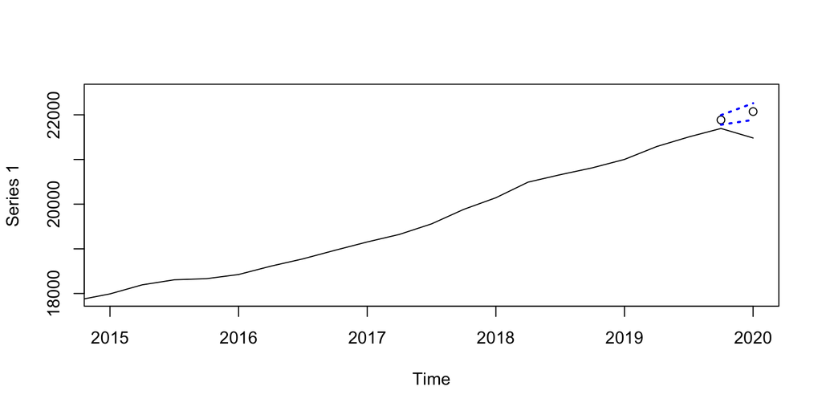

```r
selected.arima <- stats::arima(train_gdp, order=c(2,1,2), method="ML")

gdp_pred2 = forecast(selected.arima, h=2, level = 95)

plot(ts(gdp.ts,start = c(1959,1), end = c(2020,1),frequency = 4),xlim=c(2015,2020), ylim = c(17900,22500))
points(ts(gdp_pred2$mean,start = c(2019,4), end = c(2020,1),frequency = 4))

ubound = ts(gdp_pred2$lower,start = c(2019,4), end = c(2020,1),frequency = 4)#confidenec interval
lbound = ts(gdp_pred2$upper,start = c(2019,4), end = c(2020,1),frequency = 4)

lines(ubound,lty=3,lwd= 2, col="blue")
lines(lbound,lty=3,lwd= 2, col="blue")
```

```r
print(paste0('RMSE = ',sqrt(sum((gdp_pred2$mean-gdp.ts[245:246])^2)/2)))
```

```
## [1] "RMSE = 1857.05411170779"
```

*Response*

```
The undifferenced data seem to have a lower RMSE.
```

# Question 2: Multivariate Analysis using VAR modeling

For this question, divide the quarterly data into training data (excluding the first two quarters of 2020) and testing data (including the two quarters). You will apply the modeling to the training data, and we will forecast the first two quarters of 2020.

## Question 2a

Apply the VAR model to the multivariate time series including all five economic indicators observed quarterly. (Note that you will apply VAR to the training data.) Identify the VAR order using both AIC and BIC and compare. If the selected order using AIC is larger than the selected order than selected using BIC, apply the Wald test to evaluate whether a smaller order than the one selected with AIC would be a better choice, meaning the smaller order model would perform similarly than the larger order model. Interpret the order selection.

This can be done by following the below substeps:- 1)Combine the variables into a multivariate dataset 2)select/display var orders and isolate models using AIC and BIC orders 3)Isolate coefficients and covariances from the AIC model 4)applying the Wald test to the values obtained from the AIC model, but would not be present in the BIC model. You can run a single Wald test for each variable, with all the lagged coefficients for that particular variable, in all resulting in 5 wald tests.

```r
ts.merge <- merge(gdp.ts,expgs.ts, join='inner')
ts.merge <- merge(ts.merge,imgpgsc.ts, join='inner')
ts.merge <- merge(ts.merge, unrate.q.ts, join = 'inner')
ts.merge <- merge(ts.merge, pce.q.ts, join = 'inner')
colnames(ts.merge)<-c("gdp","import","export","unemployment_rate","pce")

train_merge = head(ts.merge,244)
test_merge = head(ts.merge,2)

VARselect(train_merge, lag.max = 20)
```

```
## $selection
## AIC(n)  HQ(n)  SC(n) FPE(n)
##     20      3      2      7
##
## $criteria
##                   1            2            3            4            5
## AIC(n) 2.552665e+01 2.449435e+01 2.433747e+01 2.422343e+01 2.415885e+01
## HQ(n)  2.571108e+01 2.483248e+01 2.482929e+01 2.486895e+01 2.495806e+01
## SC(n)  2.598357e+01 2.533203e+01 2.555591e+01 2.582264e+01 2.613882e+01
## FPE(n) 1.219302e+11 4.344442e+10 3.716703e+10 3.321235e+10 3.121309e+10
##                   6            7            8            9           10
## AIC(n) 2.414980e+01 2.410239e+01 2.417049e+01 2.418998e+01 2.419092e+01
## HQ(n)  2.510271e+01 2.520900e+01 2.543079e+01 2.560397e+01 2.575861e+01
## SC(n)  2.651054e+01 2.684389e+01 2.729275e+01 2.769301e+01 2.807472e+01
## FPE(n) 3.104603e+10 2.976052e+10 3.207524e+10 3.299425e+10 3.339043e+10
##                  11           12           13           14           15
## AIC(n) 2.420590e+01 2.415490e+01 2.418908e+01 2.418429e+01 2.420556e+01
## HQ(n)  2.592729e+01 2.602998e+01 2.621786e+01 2.636676e+01 2.654172e+01
## SC(n)  2.847046e+01 2.880022e+01 2.921517e+01 2.959114e+01 2.999317e+01
## FPE(n) 3.435563e+10 3.318558e+10 3.501646e+10 3.566149e+10 3.742299e+10
##                  16           17           18           19           20
## AIC(n) 2.412945e+01 2.401429e+01 2.395396e+01 2.385401e+01 2.380134e+01
## HQ(n)  2.661931e+01 2.665784e+01 2.675121e+01 2.680495e+01 2.690597e+01
## SC(n)  3.029783e+01 3.056343e+01 3.088387e+01 3.116468e+01 3.149277e+01
## FPE(n) 3.578222e+10 3.306022e+10 3.243752e+10 3.076822e+10 3.079477e+10
```

```r
mod_aic_1 = VAR(train_merge,lag.max=20,ic="AIC", type="const")
mod_aic_2 = VAR(train_merge,lag.max=20,ic="AIC", type="trend")
mod_aic_3 = VAR(train_merge,lag.max=20,ic="AIC", type="both")
pord_1 = mod_aic_1$p; pord_2 = mod_aic_2$p; pord_3 = mod_aic_3$p
mod_hq = VAR(train_merge,lag.max=20,ic="HQ")
mod_sc = VAR(train_merge,lag.max=20,ic="SC")
mod_fpe = VAR(train_merge,lag.max=20,ic="FPE")
pord_hq = mod_hq$p; pord_sc = mod_sc$p; pord_fpe = mod_fpe$p
```

```r
# Estimated coefficients and their variance for Bitcoin regression Equation

n = 5 # there are 3 different regressors
p = 20 # our var selected order

var.all = vcov(mod_aic_3)

## coefficient and variance-covariance matrix for gdp
coef.gdp = coefficients(mod_aic_3)$gdp[-(n*p+1), 1]
gdp.i = 1 # gdp is the first column
gdp.index.min = 2+(gdp.i-1)*(n*p+1)
gdp.index.max = (n*p+1)*gdp.i
gdp.index = c(gdp.index.min:gdp.index.max)
var.gdp = var.all[gdp.index,gdp.index]

## coefficient and variance-covariance matrix for import
coef.import = coefficients(mod_aic_3)$import[-(n*p+1), 1]
import.i = 2 # import is the second column
import.index.min = 2+(import.i-1)*(n*p+1)
import.index.max = (n*p+1)*import.i
import.index = c(import.index.min:import.index.max)
var.import = var.all[import.index,import.index]

## coefficient and variance-covariance matrix for export
coef.export = coefficients(mod_aic_3)$export[-(n*p+1), 1]
export.i = 3 # export500 is the third column
export.index.min = 2+(export.i-1)*(n*p+1)
export.index.max = (n*p+1)*export.i
export.index = c(export.index.min:export.index.max)
var.export = var.all[export.index,export.index]

## coefficient and variance-covariance matrix for unemployment rate
coef.unemployment_rate = coefficients(mod_aic_3)$unemployment_rate[-(n*p+1), 1]
unemployment_rate.i = 4 # unemployment_rate500 is the fourth column
unemployment_rate.index.min = 2+(unemployment_rate.i-1)*(n*p+1)
unemployment_rate.index.max = (n*p+1)*unemployment_rate.i
unemployment_rate.index = c(unemployment_rate.index.min:unemployment_rate.index.max)
var.unemployment_rate = var.all[import.index,import.index]

## coefficient and variance-covariance matrix for pce
coef.pce = coefficients(mod_aic_3)$pce[-(n*p+1), 1]
pce.i =5 # pce500 is the fifth column
pce.index.min = 2+(pce.i-1)*(n*p+1)
pce.index.max = (n*p+1)*pce.i
pce.index = c(pce.index.min:pce.index.max)
var.pce = var.all[pce.index,pce.index]
```

```r
wald.test(b=coef.gdp[1:100], var.gdp, Terms = seq(gdp.i, n*p, n))
```

```
## Wald test:
## ----------
##
## Chi-squared test:
## X2 = 295.9, df = 20, P(> X2) = 0.0
```

```r
wald.test(b=coef.gdp[1:100], var.gdp, Terms = seq(import.i, n*p, n))
```

```
## Wald test:
## ----------
##
## Chi-squared test:
## X2 = 55.0, df = 20, P(> X2) = 4.1e-05
```

```r
wald.test(b=coef.gdp[1:100], var.gdp,Terms = seq(export.i, n*p, n))
```

```
## Wald test:
## ----------
##
## Chi-squared test:
## X2 = 54.4, df = 20, P(> X2) = 5.1e-05
```

```r
wald.test(b=coef.gdp[1:100], var.gdp,Terms = seq(unemployment_rate.i, n*p, n))
```

```
## Wald test:
## ----------
##
## Chi-squared test:
## X2 = 17.4, df = 20, P(> X2) = 0.63
```

```r
wald.test(b=coef.gdp[1:100], var.gdp,Terms = seq(pce.i, n*p, n))
```

```
## Wald test:
## ----------
##
## Chi-squared test:
## X2 = 52.0, df = 20, P(> X2) = 0.00011
```

*Response*

```
The selected AIC model has 20 p lags. The wald test result shows that import, export and pce has a lead-lag relationship with gdp.
```

## Question 2b

Based on the analysis in 2a, select the VAR order using BIC and fit that model. Print out the model summary and comment on the statistical significance of the coefficients. Apply a model selection analysis using stepwise regression to select the models for each individual time series. What do you conclude from this model selection? Apply the restrict() command in R to restrict the model of order. How do the restricted models compare?

Follow the below steps to implement this: 1)Analyze the coefficients of the unrestricted model. 2)Then treat each of the series separately and do a stepwise regression by apply lm() and step() (in the backward direction with 3 steps) functions to each of the component time series to examine the coefficients 3)The stepwise regressions will return three separate models. Analyze if the same coefficients are significant in the overall VAR versus each of the stepwise models. Discuss. 4)Then build a model using restrict and see which predictors were significant in the restricted VAR model.

```r
# Model Fitting: Unrestricted VAR

unrstrcted = VAR(train_merge, p=2)
summary(unrstrcted)
```

```
##
## VAR Estimation Results:
## =========================
## Endogenous variables: gdp, import, export, unemployment_rate, pce
## Deterministic variables: const
## Sample size: 242
## Log Likelihood: -4590.213
## Roots of the characteristic polynomial:
## 1.009 0.9786 0.9786 0.9495 0.8059 0.8059 0.3523 0.3523 0.2171 0.02384
## Call:
## VAR(y = train_merge, p = 2)
##
##
## Estimation results for equation gdp:
## ====================================
## gdp = gdp.l1 + import.l1 + export.l1 + unemployment_rate.l1 + pce.l1 + gdp.l2 + import.l2 + export.l2 + unemployment_rate.l2 + pce.l2 + const
##
##                       Estimate Std. Error t value Pr(>|t|)
## gdp.l1                 1.24053    0.08407  14.756  < 2e-16 ***
## import.l1             -0.05900    0.15708  -0.376   0.7075
## export.l1              0.61018    0.14409   4.235 3.31e-05 ***
## unemployment_rate.l1 -13.88253   10.74571  -1.292   0.1977
## pce.l1                -0.04535    0.12278  -0.369   0.7122
## gdp.l2                -0.20571    0.09197  -2.237   0.0263 *
## import.l2             -0.02598    0.15757  -0.165   0.8692
## export.l2             -0.62147    0.14569  -4.266 2.91e-05 ***
## unemployment_rate.l2  15.98737   10.78624   1.482   0.1396
## pce.l2                 0.02166    0.11127   0.195   0.8458
## const                 -9.49036   18.67542  -0.508   0.6118
## ---
## Signif. codes:  0 '***' 0.001 '**' 0.01 '*' 0.05 '.' 0.1 ' ' 1
##
##
## Residual standard error: 51.15 on 231 degrees of freedom
## Multiple R-Squared: 0.9999,  Adjusted R-squared: 0.9999
## F-statistic: 3.627e+05 on 10 and 231 DF,  p-value: < 2.2e-16
##
##
## Estimation results for equation import:
## =======================================
```

[output cut: 99 more lines]

```
## Covariance matrix of residuals:
##                        gdp  import  export unemployment_rate      pce
## gdp               2616.657 807.180 394.751          -2.14165  975.718
## import             807.180 624.334 242.657          -0.47096  349.345
## export             394.751 242.657 609.900          -1.36627  231.194
## unemployment_rate   -2.142  -0.471  -1.366           0.08386   -0.978
## pce                975.718 349.345 231.194          -0.97803 1027.730
##
## Correlation matrix of residuals:
##                       gdp   import  export unemployment_rate     pce
## gdp                1.0000  0.63152  0.3125          -0.14458  0.5950
## import             0.6315  1.00000  0.3932          -0.06509  0.4361
## export             0.3125  0.39324  1.0000          -0.19104  0.2920
## unemployment_rate -0.1446 -0.06509 -0.1910           1.00000 -0.1054
## pce                0.5950  0.43612  0.2920          -0.10535  1.0000
```

```r
# Model Fitting: Restricted VAR

rstrcted = restrict(unrstrcted)
summary(rstrcted)
```

```
##
## VAR Estimation Results:
## =========================
## Endogenous variables: gdp, import, export, unemployment_rate, pce
## Deterministic variables: const
## Sample size: 242
## Log Likelihood: -4602.489
## Roots of the characteristic polynomial:
##  1.01 0.9788 0.9788 0.9499 0.7277 0.7277 0.6145 0.3687 0.2019 0.05747
## Call:
## VAR(y = train_merge, p = 2)
##
##
## Estimation results for equation gdp:
## ====================================
## gdp = gdp.l1 + import.l1 + export.l1 + gdp.l2 + export.l2
##
##           Estimate Std. Error t value Pr(>|t|)
## gdp.l1     1.26315    0.06356  19.872  < 2e-16 ***
## import.l1 -0.09372    0.02277  -4.117 5.31e-05 ***
## export.l1  0.65870    0.12648   5.208 4.14e-07 ***
## gdp.l2    -0.24017    0.06469  -3.713 0.000256 ***
## export.l2 -0.68957    0.12694  -5.432 1.38e-07 ***
## ---
## Signif. codes:  0 '***' 0.001 '**' 0.01 '*' 0.05 '.' 0.1 ' ' 1
##
##
## Residual standard error: 50.91 on 237 degrees of freedom
## Multiple R-Squared:     1,   Adjusted R-squared:     1
## F-statistic: 1.756e+06 on 5 and 237 DF,  p-value: < 2.2e-16
##
##
## Estimation results for equation import:
## =======================================
## import = import.l1 + pce.l1 + import.l2 + pce.l2
##
##           Estimate Std. Error t value Pr(>|t|)
## import.l1  1.61201    0.06260  25.751  < 2e-16 ***
## pce.l1    -0.15459    0.04448  -3.476 0.000606 ***
## import.l2 -0.66701    0.06376 -10.462  < 2e-16 ***
```

[output cut: 75 more lines]

```
## Covariance matrix of residuals:
##                        gdp   import export unemployment_rate       pce
## gdp               2656.076 818.9654 404.15          -2.15165  993.6199
## import             818.965 645.1745 248.21          -0.50939  362.6651
## export             404.152 248.2116 614.69          -1.38958  235.4617
## unemployment_rate   -2.152  -0.5094  -1.39           0.08503   -0.9913
## pce                993.620 362.6651 235.46          -0.99127 1047.1523
##
## Correlation matrix of residuals:
##                       gdp   import  export unemployment_rate     pce
## gdp                1.0000  0.62561  0.3163          -0.14318  0.5958
## import             0.6256  1.00000  0.3941          -0.06878  0.4412
## export             0.3163  0.39415  1.0000          -0.19221  0.2935
## unemployment_rate -0.1432 -0.06878 -0.1922           1.00000 -0.1051
## pce                0.5958  0.44123  0.2935          -0.10505  1.0000
```

```r
# Fit the full model
full.model <- lm(gdp ~., data = train_merge)
# Stepwise regression model
step.model <- step(full.model, direction = "backward",
                      trace = 1, steps = 3)
```

```
## Start:  AIC=2367.43
## gdp ~ import + export + unemployment_rate + pce
##
##                     Df Sum of Sq      RSS    AIC
## <none>                            3831565 2367.4
## - unemployment_rate  1    123239  3954804 2373.2
## - import             1    369782  4201347 2387.9
## - export             1    672275  4503841 2404.9
## - pce                1  79566756 83398321 3117.0
```

```r
summary(step.model)
```

```
##
## Call:
## lm(formula = gdp ~ import + export + unemployment_rate + pce,
##     data = train_merge)
##
## Residuals:
##     Min      1Q  Median      3Q     Max
## -386.71 -104.62   16.18   85.10  294.57
##
## Coefficients:
##                    Estimate Std. Error t value Pr(>|t|)
## (Intercept)       321.46699   38.59912   8.328 6.40e-15 ***
## import             -0.33943    0.07067  -4.803 2.76e-06 ***
## export             -0.48867    0.07546  -6.476 5.32e-10 ***
## unemployment_rate -15.74939    5.68040  -2.773    0.006 **
## pce                 1.64958    0.02342  70.449  < 2e-16 ***
## ---
## Signif. codes:  0 '***' 0.001 '**' 0.01 '*' 0.05 '.' 0.1 ' ' 1
##
## Residual standard error: 126.6 on 239 degrees of freedom
## Multiple R-squared:  0.9996, Adjusted R-squared:  0.9996
## F-statistic: 1.494e+05 on 4 and 239 DF,  p-value: < 2.2e-16
```

*Response*

[output not shown]

## Question 2c

Evaluate the goodness of fit for the restricted BIC model using the multivariate ARCH test, the Jarque-Bera test and the Portmanteau test. State which assumptions are satisfied, and which are violated. (Note: While we evaluate the residuals for the normality assumption, we do not necessarily assume normality of the data. We use the normality assumption if we use the t-test to evaluate statistical significance.)

```r
# ARCH-LM test: This function computes univariate and multivariate ARCH-LM tests for a VAR(p).
arch.test(rstrcted, lags.single=2, multivariate.only = TRUE)
```

```
##
##  ARCH (multivariate)
##
## data:  Residuals of VAR object rstrcted
## Chi-squared = 2238.6, df = 1125, p-value < 2.2e-16
```

```r
# Jarque-Bera Test: This function computes univariate and multivariate Jarque-Bera tests and multivariate skewness and kurtosis tests for the residuals of a VAR(p) or of a VECM in levels.
normality.test(rstrcted, multivariate.only = TRUE)
```

```
## $JB
##
##  JB-Test (multivariate)
##
## data:  Residuals of VAR object rstrcted
## Chi-squared = 2521.4, df = 10, p-value < 2.2e-16
##
##
## $Skewness
##
##  Skewness only (multivariate)
##
## data:  Residuals of VAR object rstrcted
## Chi-squared = 127.65, df = 5, p-value < 2.2e-16
##
##
## $Kurtosis
##
##  Kurtosis only (multivariate)
##
## data:  Residuals of VAR object rstrcted
## Chi-squared = 2393.8, df = 5, p-value < 2.2e-16
```

```r
# Portmanteau: Compute the Box–Pierce or Ljung–Box test statistic for examining the null hypothesis of independence in a given time series. These are sometimes known as ‘portmanteau’ tests.
serial.test(rstrcted,lags.pt=2)
```

```
##
##  Portmanteau Test (asymptotic)
##
## data:  Residuals of VAR object rstrcted
## Chi-squared = 72.92, df = 0, p-value < 2.2e-16
```

*Response*

```
The ARCH test shows that there is autoregressive conditional heteroscedasticity because the p value is extremely small. The normality test shows that the data is not multivariate-normal distributed because the p value is extremely small. And the last Portmanteau test result shows that the errors are serially correlated.
```

## Question 2d

Using the VAR model with the order selected using BIC, forecast the first two quarters of 2020 using the unrestricted and restricted VAR. Include 95% confidence intervals. Compare the predictions to the observed data. (You don’t need to plot them (but can if you’d like). Using mean absolute percentage error and the precision measure, compare the predictions for GDP derived from the univariate analysis (Question 1) and this multivariate analysis. Discuss on the differences or similarities.

```r
vars_pred = predict(unrstrcted, n.ahead=2,interval = 'prediction', level = 0.95)
vars_pred2 = predict(rstrcted, n.ahead=2,interval = 'prediction', level=0.95)

gdp_pred3 = vars_pred$fcst$gdp
gdp_pred4 = vars_pred2$fcst$gdp
```

```r
print(paste0('RMSE = ',sqrt(sum((gdp_pred3[,1]-gdp.ts[245:246])^2)/2)))
```

```
## [1] "RMSE = 1815.47132249943"
```

```r
print(paste0('RMSE = ',sqrt(sum((gdp_pred4[,1]-gdp.ts[245:246])^2)/2)))
```

```
## [1] "RMSE = 1832.71549082351"
```

*Response*

```
Compared to the previous AIC models, the BIC models has lower RMSE, especially with the unrestricted model, the RMSE is the lowest.
```

## Question 2e

Perform a Granger Causality analysis using Wald test to evaluate whether any of the economic indicators lead GDP. Would any of the indicators help in predicting or explaining GDP for next quarters? Provide your interpretation based on the Granger causality as well as for forecasting comparison in (2d).For this, use the unrestricted bic model from Question 2a.

```r
wald.test(b=coef.gdp[1:100], var.gdp, Terms = seq(gdp.i, n*p, n))
```

```
## Wald test:
## ----------
##
## Chi-squared test:
## X2 = 295.9, df = 20, P(> X2) = 0.0
```

```r
wald.test(b=coef.gdp[1:100], var.gdp, Terms = seq(import.i, n*p, n))
```

```
## Wald test:
## ----------
##
## Chi-squared test:
## X2 = 55.0, df = 20, P(> X2) = 4.1e-05
```

```r
wald.test(b=coef.gdp[1:100], var.gdp,Terms = seq(export.i, n*p, n))
```

```
## Wald test:
## ----------
##
## Chi-squared test:
## X2 = 54.4, df = 20, P(> X2) = 5.1e-05
```

```r
wald.test(b=coef.gdp[1:100], var.gdp,Terms = seq(unemployment_rate.i, n*p, n))
```

```
## Wald test:
## ----------
##
## Chi-squared test:
## X2 = 17.4, df = 20, P(> X2) = 0.63
```

```r
wald.test(b=coef.gdp[1:100], var.gdp,Terms = seq(pce.i, n*p, n))
```

```
## Wald test:
## ----------
##
## Chi-squared test:
## X2 = 52.0, df = 20, P(> X2) = 0.00011
```

*Response*

```
The wald test result shows that import, export and pce has a lead-lag relationship with gdp.
```

# Question 3

For this question, consider the training data to include the time values up to December 2017 and the testing data to include the first two quarters of 2018.

## Question 3a

Apply the VAR modeling approach with the order selected using the BIC approach giving the unrestricted VAR model. Apply a model selection analysis using stepwise regression to select the models for each individual time series. Based on the selected models, form the restricted VAR model, much like what was presented in the Moose R example code. Compare these two models in terms of coefficients and their statistical significance with the models derived in Question 2.

Follow the below steps to implement this: 1)Analyze the coefficients of the unrestricted model. 2)Then treat each of the series separately and do a stepwise regression by apply lm() and step()(in the backward direction with 3 steps) functions to each of the component time series to examine the coefficients 3)The stepwise regressions will return three separate models. Analyze if the same coefficients are significant in the overall VAR versus each of the stepwise models. Discuss. 4)Then build a model using restrict and see which predictors were significant in the restricted VAR model.

## Question 3b

Forecast the first two quarters of 2018 using the unrestricted and restricted VAR models derived in (3a). Include 95% confidence intervals. Compare the predictions to the observed data using mean absolute percentage error and the precision measure for GDP. Compare the predictions to those derived in (2d). Comment on the accuracy of the predictions.

## Question 3c

Perform a Granger Causality analysis using Wald test to evaluate whether any of the economic indicators lead GDP. Would any of the indicators help in predicting or explaining GDP for next quarters? Provide your interpretation based on the Granger causality as well as for forecasting comparison in (3b). Compare this analysis with the findings in (2e). For this question, use the unrestricted VAR model from Question 3a.

# Question 4: Reflection

From what you encountered above and your conceptual understanding of VAR modelling, reflect on the relative strengths and weaknesses of the modelling approach. Particularly, you will need to put this analysis into the perspective of the results you found and any relevant economic events you might be potentially able to link them to.